# Подготовка экспериментального стенда GNS3

Лабораторная работа №4

Суннатилло Махмудов

Российский университет дружбы народов, Москва, Россия

17 октября 2025

# Цели и задачи работы

## Цель лабораторной работы

Установка и настройка среды **GNS3** и добавление виртуальных маршрутизаторов для моделирования сетевой инфраструктуры.

## Задачи лабораторной работы

1. Развернуть **GNS3 VM** в гипервизоре.
2. Настроить подключение приложения GNS3 к серверу.
3. Добавить образы маршрутизаторов **FRRouting (FRR)** и **VyOS**.
4. Проверить успешный запуск и доступность устройств через консоль.

# Теоретическая часть

## Назначение GNS3

- **GNS3 (Graphical Network Simulator 3)** — инструмент для моделирования сетей.
- Позволяет создавать топологии с виртуальными маршрутизаторами и коммутаторами.
- Поддерживает интеграцию с **VMware**, **VirtualBox** и **QEMU**.
- Используется в обучении, тестировании и отладке сетевых решений.

## Особенности протоколов

- **FRRouting (FRR)** — реализация динамической маршрутизации (OSPF, BGP, RIP).
- **VyOS** — дистрибутив Linux для построения маршрутизаторов и VPN.
- В GNS3 эти образы эмулируются с помощью QEMU.

# Выполнение работы

## Запуск GNS3 VM

- Виртуальная машина запущена в **VMware**.

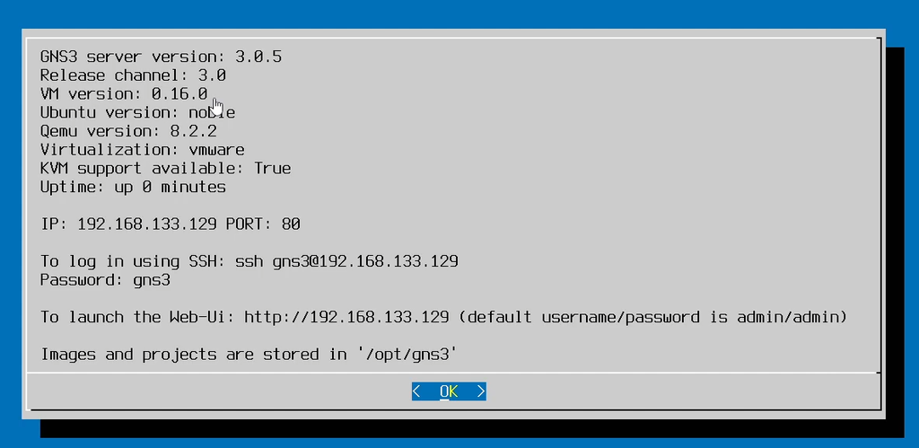

Информация о GNS3 сервере

## Подключение к серверу

- В **Setup Wizard** выбраны настройки подключения
- Соединение установлено успешно.

[figure not shown]

Настройка подключения к контроллеру GNS3

## Добавление маршрутизатора FRR

- В мастере установки выбран образ **FRRouting 8.1.0**.
- Образ установлен на виртуальную машину **GNS3 VM**.

[figure not shown]

## Проверка запуска FRR

- Вход через **PuTTY**.
- Приветствие **Alpine Linux**, запущен сервис **FRRouting**.

[figure not shown]

Консоль маршрутизатора FRR

## Добавление маршрутизатора VyOS

- Установлен образ **VyOS 1.3.3-qemu**.
- После запуска через **PuTTY** отображается приглашение входа в систему.

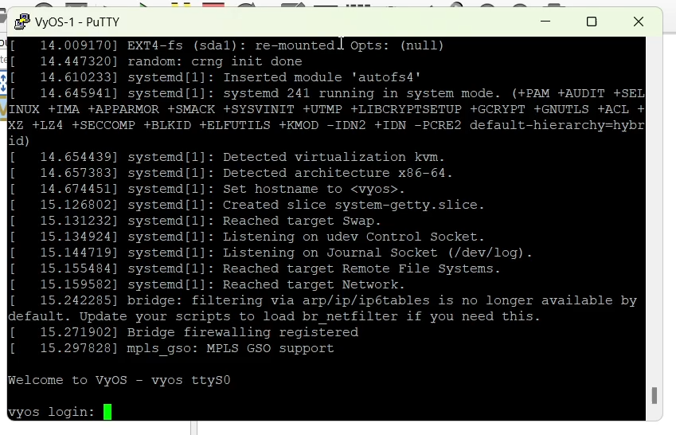

Запуск маршрутизатора VyOS

# Вывод

- Среда **GNS3** успешно развернута на базе **VMware**.
- Добавлены образы маршрутизаторов **FRR** и **VyOS**.
- Подключение и эмуляция устройств прошли успешно.
- Использование **VMware** позволило избежать сбоев, возникавших при работе в **VirtualBox**.